# FA21 Agency Campaign Vendor Reports

Office of Marketing and Brand Management

2020-03-12

### Undergraduate

**Facebook Display**

This report summarizes performance from 2020-01-13 through 2020-03-09

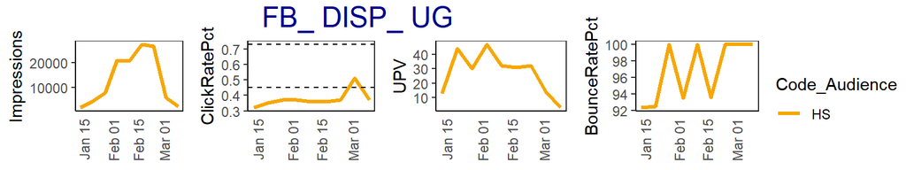

| Code_Audience | YTD_Impressions | Avg_CTR | YTD_UPV | Avg_BR |
| --- | --- | --- | --- | --- |
| HS | 118,149 | 0.37% | 246 | 96.27% |

**Facebook Video**

This report summarizes performance from 2020-02-24 through 2020-03-09

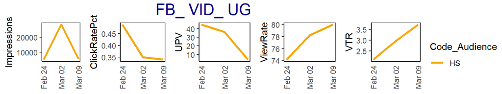

| Code_Audience | YTD_Impressions | ClickRatePct | YTD_UPV | Avg_BR | Avg_View_Rate | Avg_VTR |
| --- | --- | --- | --- | --- | --- | --- |
| HS | 39,519 | 0.36% | 85 | 98.78% | 77.93% | 3.81% |

**Instagram Display**

This report summarizes performance from 2020-01-13 through 2020-03-09

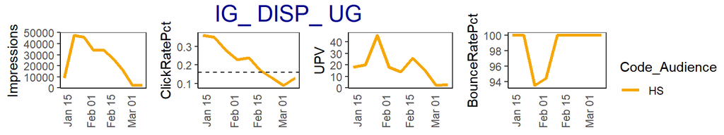

| Code_Audience | YTD_Impressions | Avg_CTR | YTD_UPV | Avg_BR |
| --- | --- | --- | --- | --- |
| HS | 218,671 | 0.26% | 163 | 97.55% |

**Instagram Video**

This report summarizes performance from 2020-01-13 through 2020-03-09

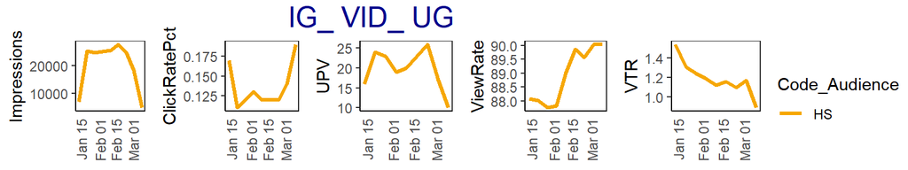

| Code_Audience | YTD_Impressions | ClickRatePct | YTD_UPV | Avg_BR | Avg_View_Rate | Avg_VTR |
| --- | --- | --- | --- | --- | --- | --- |
| HS | 183,304 | 0.13% | 178 | 97.19% | 88.84% | 1.34% |

**Instagram Stories**

This report summarizes performance from 2020-02-24 through 2020-03-09

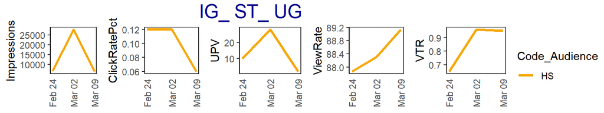

| Code_Audience | YTD_Impressions | ClickRatePct | YTD_UPV | Avg_BR | Avg_View_Rate | Avg_VTR |
| --- | --- | --- | --- | --- | --- | --- |
| HS | 40,591 | 0.11% | 40 | 95% | 88.35% | 1.03% |

**Programmatic Display**

This report summarizes performance from 2020-01-20 through 2020-03-09

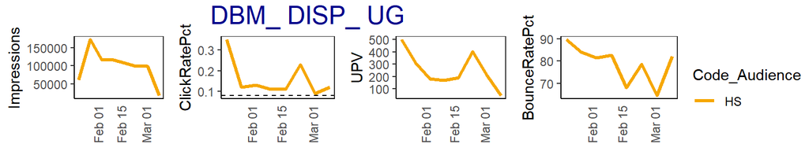

| Code_Audience | YTD_Impressions | Avg_CTR | YTD_UPV | Avg_BR |
| --- | --- | --- | --- | --- |
| HS | 788,509 | 0.15% | 2,007 | 80.57% |

**Pinterest Display**

This report summarizes performance from 2020-02-24 through 2020-03-09

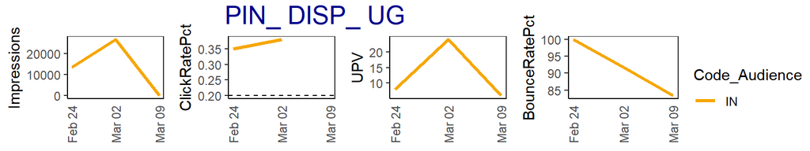

| Code_Audience | YTD_Impressions | Avg_CTR | YTD_UPV | Avg_BR |
| --- | --- | --- | --- | --- |
| IN | 40,289 | 0.37% | 38 | 92.11% |

**Pinterest Video**

This report summarizes performance from 2020-02-24 through 2020-03-09

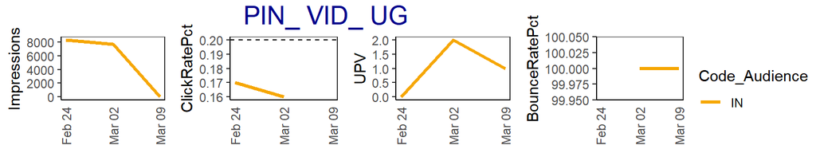

| Code_Audience | YTD_Impressions | Avg_CTR | YTD_UPV | Avg_BR |
| --- | --- | --- | --- | --- |
| IN | 15,955 | 0.16% | 3 | 100% |

**Snapchat Video**

This report summarizes performance from 2020-01-13 through 2020-03-09

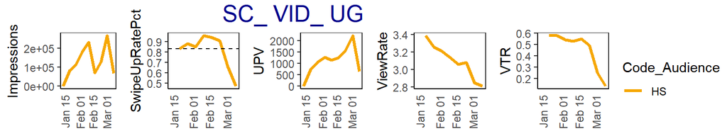

| Code_Audience | YTD_Impressions | Avg_Swipe_Rate | YTD_UPV | Avg_BR | Avg_View_Rate | Avg_VTR |
| --- | --- | --- | --- | --- | --- | --- |
| HS | 1,139,458 | 0.82% | 9,962 | 97.92% | 3.08% | 14.55% |

### Transfer

**Programmatic Display**

This report summarizes performance from 2020-02-24 through 2020-03-09

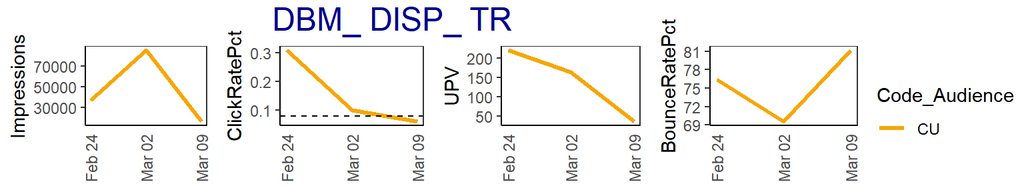

| Code_Audience | YTD_Impressions | Avg_CTR | YTD_UPV | Avg_BR |
| --- | --- | --- | --- | --- |
| CU | 138,578 | 0.16% | 422 | 74.1% |

**Facebook Video**

This report summarizes performance from 2020-02-24 through 2020-03-09

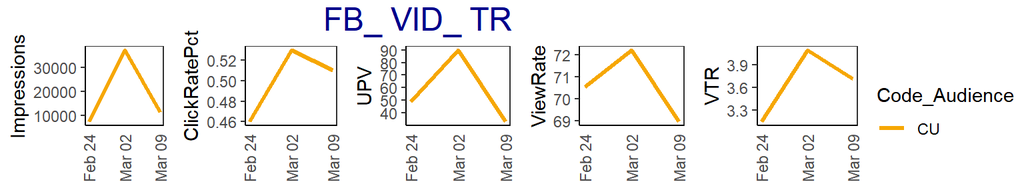

| Code_Audience | YTD_Impressions | ClickRatePct | YTD_UPV | Avg_BR | Avg_View_Rate | Avg_VTR |
| --- | --- | --- | --- | --- | --- | --- |
| CU | 55,856 | 0.51% | 172 | 95.78% | 71.35% | 5.46% |

**Instagram Video**

This report summarizes performance from 2020-02-24 through 2020-03-09

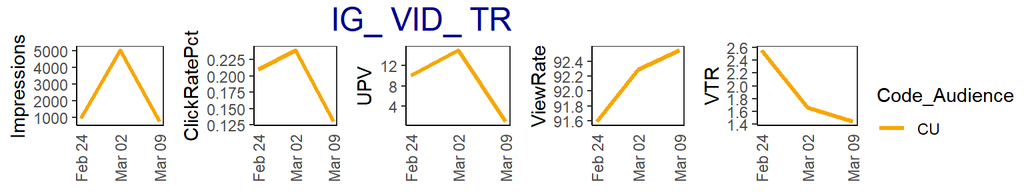

| Code_Audience | YTD_Impressions | ClickRatePct | YTD_UPV | Avg_BR | Avg_View_Rate | Avg_VTR |
| --- | --- | --- | --- | --- | --- | --- |
| CU | 6,800 | 0.22% | 26 | 83.33% | 92.22% | 1.91% |

**Instagram Stories**

This report summarizes performance from 2020-02-24 through 2020-03-09

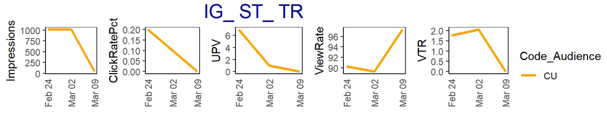

| Code_Audience | YTD_Impressions | ClickRatePct | YTD_UPV | Avg_BR | Avg_View_Rate | Avg_VTR |
| --- | --- | --- | --- | --- | --- | --- |
| CU | 2,073 | 0.14% | 8 | 100% | 89.92% | 2.09% |

**Snapchat Video**

This report summarizes performance from 2020-02-24 through 2020-03-09

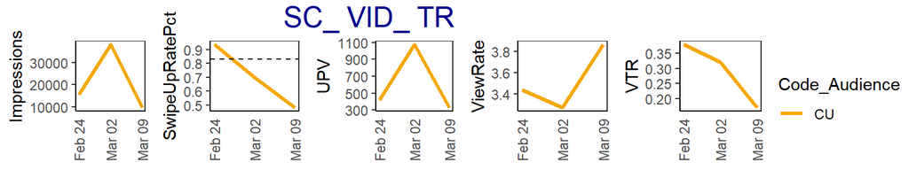

| Code_Audience | YTD_Impressions | Avg_Swipe_Rate | YTD_UPV | Avg_BR | Avg_View_Rate | Avg_VTR |
| --- | --- | --- | --- | --- | --- | --- |
| CU | 63,245 | 0.73% | 1,825 | 98.63% | 3.4% | 9.08% |

### Degree Completion

**Programmatic Display**

This report summarizes performance from 2020-02-24 through 2020-03-09

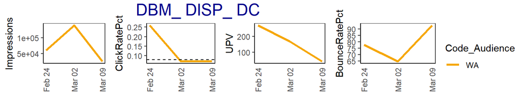

| Code_Audience | YTD_Impressions | Avg_CTR | YTD_UPV | Avg_BR |
| --- | --- | --- | --- | --- |
| WA | 224,366 | 0.12% | 480 | 74.45% |

**Facebook Video**

This report summarizes performance from 2020-02-24 through 2020-03-09

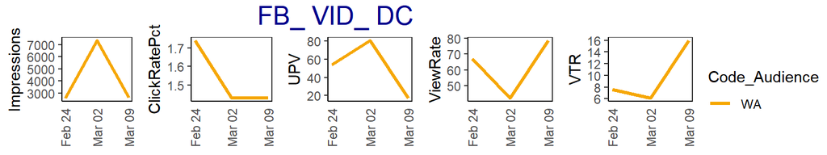

| Code_Audience | YTD_Impressions | ClickRatePct | YTD_UPV | Avg_BR | Avg_View_Rate | Avg_VTR |
| --- | --- | --- | --- | --- | --- | --- |
| WA | 12,599 | 1.49% | 152 | 93.15% | 54.95% | 15.44% |

**Instagram Video**

This report summarizes performance from 2020-02-24 through 2020-03-09

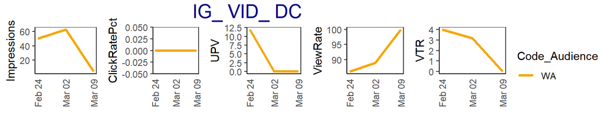

| Code_Audience | YTD_Impressions | ClickRatePct | YTD_UPV | Avg_BR | Avg_View_Rate | Avg_VTR |
| --- | --- | --- | --- | --- | --- | --- |
| WA | 117 | 0% | 12 | 100% | 88.03% | 3.88% |

**Gmail InBox**

This report summarizes performance from 2020-02-24 through 2020-03-09

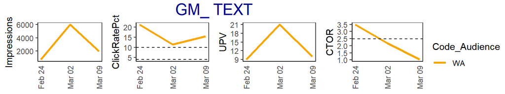

| Code_Audience | YTD_Impressions | Avg_CTR | YTD_UPV | Avg_CTOR | Avg_BR |
| --- | --- | --- | --- | --- | --- |
| WA | 8,616 | 13.12% | 40 | 2.04% | 58.33% |

**LinkedIn Sponsored InMail**

This report summarizes performance from 2020-02-24 through 2020-03-09

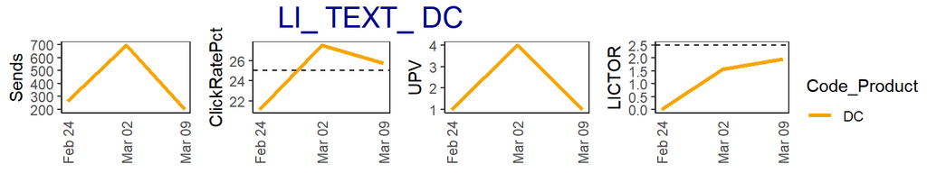

| Code_Product | YTD_Sends | Avg_OR | YTD_UPV | Avg_CTOR |
| --- | --- | --- | --- | --- |
| DC | 1,160 | 25.78 | 6 | 1.34% |

### Graduate

**Programmatic Display**

This report summarizes performance from 2020-02-24 through 2020-03-09

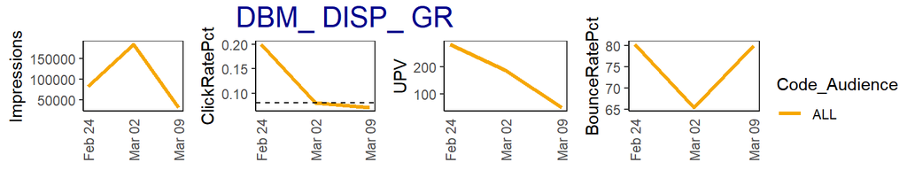

| Code_Audience | YTD_Impressions | Avg_CTR | YTD_UPV | Avg_BR |
| --- | --- | --- | --- | --- |
| ALL | 297,313 | 0.11% | 519 | 75% |

**Facebook Video**

This report summarizes performance from 2020-02-24 through 2020-03-09

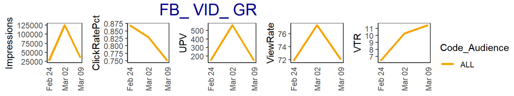

| Code_Audience | YTD_Impressions | ClickRatePct | YTD_UPV | Avg_BR | Avg_View_Rate | Avg_VTR |
| --- | --- | --- | --- | --- | --- | --- |
| ALL | 187,092 | 0.82% | 859 | 90.09% | 75.57% | 13.18% |

**Instagram Video**

This report summarizes performance from 2020-02-24 through 2020-03-09

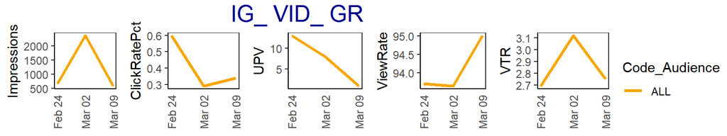

| Code_Audience | YTD_Impressions | ClickRatePct | YTD_UPV | Avg_BR | Avg_View_Rate | Avg_VTR |
| --- | --- | --- | --- | --- | --- | --- |
| ALL | 3,623 | 0.36% | 22 | 100% | 93.87% | 3.18% |

**LinkedIn Sponsored InMail**

This report summarizes performance from 2020-02-24 through 2020-03-09

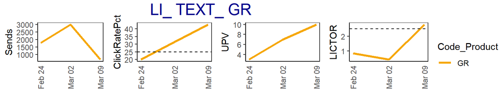

| Code_Product | YTD_Sends | Avg_OR | YTD_UPV | Avg_CTOR |
| --- | --- | --- | --- | --- |
| GR | 5,453 | 29.18 | 20 | 0.94% |